# CMSC320 Final Tutorial: Predicting Stroke

## Introduction

[Strokes](https://www.mayoclinic.org/diseases-conditions/stroke/symptoms-causes/syc-20350113) occur when blood supply to part of your brain is interrupted or reduced. This prevents brain tissue from getting oxygen and nutrients and as a result, brain cells begin to die in minutes.

According to the CDC, stroke is the 5th leading cause of death in the United States. In fact, someone in the U.S. dies of stroke approximately every [4 minutes](https://www.cdc.gov/stroke/facts.htm). The statistics are startling and predicting stroke can be [very difficult](https://www.news-medical.net/health/Biomarkers-for-Prediction-of-Stroke.aspx) due to many different pathophysiologies. Stroke warnings can occur hours or even days before the attack. Without urgent treatment, serious damage can occur to the brain and can result in negative repercussions.

I'm interested to see if we can utilize data science in order to investigate what factors might be related to strokes. In this tutorial, we will use data to examine the relationship between stroke and various factors like gender, age, smoking status, etc. We will try to predict strokes among patients using Machine Learning algorithms and analyze them to find which factors may have contributed to strokes. Hopefully after this tutorial, we can have a better idea of correlated causes in order to better reliably predict strokes.

## Set Up

Here are the Python libraries/packages we will be utilizing in this tutorial. Also feel free to refer to the Python tutorial in Additional Resources at the bottom if you are unfamilar with Python.

```python
import pandas as pd
import numpy as np
import matplotlib.pyplot as plt
import seaborn as sns
import sklearn
from imblearn.over_sampling import SMOTE
from sklearn.linear_model import LogisticRegression
from sklearn.ensemble import RandomForestClassifier
from sklearn.model_selection import train_test_split, cross_val_score, KFold, GridSearchCV
from sklearn.neighbors import KNeighborsClassifier
from sklearn.metrics import accuracy_score, confusion_matrix
from sklearn.preprocessing import LabelEncoder
```

## Obtaining Data

In this tutorial, we will be using a data set about strokes that is available to us from [Kaggle](https://www.kaggle.com/fedesoriano/stroke-prediction-dataset).

- [healthcare-dataset-stroke-data.csv](https://www.kaggle.com/fedesoriano/stroke-prediction-dataset): the data consists of 5110 observations and 12 different attributes

First, let's load our data into a Pandas data frame and examine our data set.

```python
df = pd.read_csv("healthcare-dataset-stroke-data.csv")

# Display first five rows
df.head()
```

|  | id | gender | age | hypertension | heart_disease | ever_married | work_type | Residence_type | avg_glucose_level | bmi | smoking_status | stroke |
| --- | --- | --- | --- | --- | --- | --- | --- | --- | --- | --- | --- | --- |
| 0 | 9046 | Male | 67.0 | 0 | 1 | Yes | Private | Urban | 228.69 | 36.6 | formerly smoked | 1 |
| 1 | 51676 | Female | 61.0 | 0 | 0 | Yes | Self-employed | Rural | 202.21 | NaN | never smoked | 1 |
| 2 | 31112 | Male | 80.0 | 0 | 1 | Yes | Private | Rural | 105.92 | 32.5 | never smoked | 1 |
| 3 | 60182 | Female | 49.0 | 0 | 0 | Yes | Private | Urban | 171.23 | 34.4 | smokes | 1 |
| 4 | 1665 | Female | 79.0 | 1 | 0 | Yes | Self-employed | Rural | 174.12 | 24.0 | never smoked | 1 |

## Cleaning the Data

In order to avoid future issues with data analysis and get meaningful results, it is important that we clean the data to make sure it is tidy.

We can see already above that there are some missing values in the data set (specified by the NaN entry). Let's see how many there currently are.

```python
df.isna().sum()
```

```
id                     0
gender                 0
age                    0
hypertension           0
heart_disease          0
ever_married           0
work_type              0
Residence_type         0
avg_glucose_level      0
bmi                  201
smoking_status         0
stroke                 0
dtype: int64
```

There are 201 missing values in the bmi column. First, let's remove outliers. More specifically, according to an [NHSN announcement](https://www.cdc.gov/nhsn/pdfs/commup/email-update-nov17.pdf), BMI values are considered outliers if they are less than 12 or greater than 60. We are going to remove this from the data set by replacing them with NaN to avoid skewed data.

```python
# Replace BMI outliers with NaN
df['bmi'] = df['bmi'].apply(lambda bmi_val: bmi_val if 12 < bmi_val < 60 else np.nan)
```

We already saw that there were 201 missing values in the data set. Now, there are going to be additional NaN entries since we just replace BMI outliers as well. Let's see how many missing entries there are now.

```python
df.isna().sum()
```

```
id                     0
gender                 0
age                    0
hypertension           0
heart_disease          0
ever_married           0
work_type              0
Residence_type         0
avg_glucose_level      0
bmi                  218
smoking_status         0
stroke                 0
dtype: int64
```

Now, there are 218 missing values. There were 17 outliers in the bmi column! In order to address missing values, we can either choose to replace the missing values with another value so it is no longer null OR we can choose to completely drop any rows with missing values. For this particular data set, I am going to replace the missing values with the mean of the bmi column.

```python
# Calculate mean of bmi column
bmi_mean = df['bmi'].mean()

# Replace missing values of bmi column with bmi_mean
df['bmi'] = df['bmi'].fillna(bmi_mean)

df.isna().sum()
```

```
id                   0
gender               0
age                  0
hypertension         0
heart_disease        0
ever_married         0
work_type            0
Residence_type       0
avg_glucose_level    0
bmi                  0
smoking_status       0
stroke               0
dtype: int64
```

Great! Now there are no missing values in our data set.

It's also important to check for duplicated entries, which can be due to data entry errors or data collection methods. Fortunately, there doesn't seem to be any duplicated entries in the data set.

```python
df.duplicated().sum()
```

```
0
```

While it is typically not a major problem with data analysis, I am going to go a step further to tidy the data set by standardizing the column names since I notice "Residence_type" is capitalized unlike all other column names. Tidy data should be consistent!

```python
df = df.rename(columns={'Residence_type': 'residence_type'})
```

Finally, we can drop the 'id' column since it is not necessary in data analysis and we know that all entries are unique/not duplicated.

```python
df = df.drop(['id'], axis=1)

df
```

|  | gender | age | hypertension | heart_disease | ever_married | work_type | residence_type | avg_glucose_level | bmi | smoking_status | stroke |
| --- | --- | --- | --- | --- | --- | --- | --- | --- | --- | --- | --- |
| 0 | Male | 67.0 | 0 | 1 | Yes | Private | Urban | 228.69 | 36.600000 | formerly smoked | 1 |
| 1 | Female | 61.0 | 0 | 0 | Yes | Self-employed | Rural | 202.21 | 28.799714 | never smoked | 1 |
| 2 | Male | 80.0 | 0 | 1 | Yes | Private | Rural | 105.92 | 32.500000 | never smoked | 1 |
| 3 | Female | 49.0 | 0 | 0 | Yes | Private | Urban | 171.23 | 34.400000 | smokes | 1 |
| 4 | Female | 79.0 | 1 | 0 | Yes | Self-employed | Rural | 174.12 | 24.000000 | never smoked | 1 |
| ... | ... | ... | ... | ... | ... | ... | ... | ... | ... | ... | ... |
| 5105 | Female | 80.0 | 1 | 0 | Yes | Private | Urban | 83.75 | 28.799714 | never smoked | 0 |
| 5106 | Female | 81.0 | 0 | 0 | Yes | Self-employed | Urban | 125.20 | 40.000000 | never smoked | 0 |
| 5107 | Female | 35.0 | 0 | 0 | Yes | Self-employed | Rural | 82.99 | 30.600000 | never smoked | 0 |
| 5108 | Male | 51.0 | 0 | 0 | Yes | Private | Rural | 166.29 | 25.600000 | formerly smoked | 0 |
| 5109 | Female | 44.0 | 0 | 0 | Yes | Govt_job | Urban | 85.28 | 26.200000 | Unknown | 0 |

5110 rows × 11 columns

## Exploratory Data Analysis

Now we will perform exploratory data analysis, or EDA for short. In this stage, we try to better understand our data set, typically through data visualization, in order to look for potential trends or any strong relationships between various attributes and our target variable: stroke.

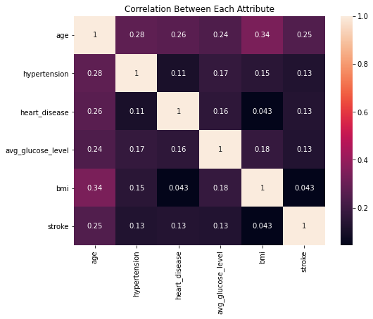

```python
# Calculates correlation between numerical values in the data set.
data_corr = df.corr()

plt.figure(figsize=(8, 6))

# Generate correlation matrix
sns.heatmap(data_corr, annot= True)
plt.title("Correlation Between Each Attribute")
plt.show()
```

We have generated a correlation matrix that displays the correlation coefficients between each attribute of the data set. Boxes that are lighter in color (closer to 1.0) indicate a stronger positive correlation whereas boxes that are darker in color (closer to 0) indicate that there is less of a correlation between the two variables.

In our generated correlation matrix, we can see that most of the boxes are darker colored. We are most interested in the last row (or column) of the correlation matrix, which shows the correlation (or lackthereof) between stroke and the other dependent variables.

### Stroke vs Age

I am interested to see the relationship between stroke vs age. I can predict that there will be a positive relationship but let's visualize this with our data set.

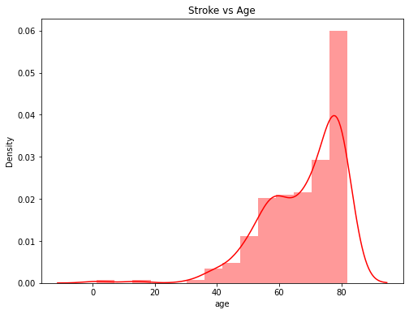

```python
had_stroke = df['stroke'] == 1

plt.figure(figsize=(8, 6))

sns.distplot(df[had_stroke]['age'], color = 'red')

plt.title('Stroke vs Age')
plt.show()
```

As we predicted, you can clearly tell people who are older are more likely to experience a stroke. Those that are aged 40 or older increase their chances of getting a stroke, but the chances increase greatly for people ages 60+.

### Age vs BMI

Now let's compare age to bmi with a scatterplot.

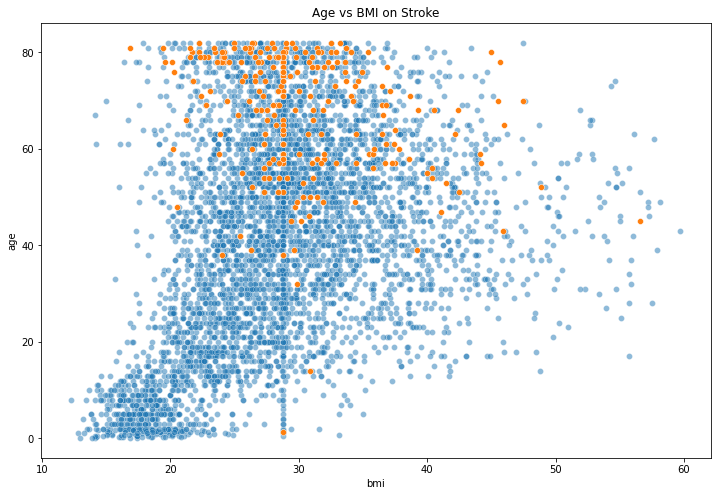

```python
had_stroke = df['stroke'] == 1
no_stroke = df['stroke'] == 0

plt.figure(figsize=(12, 8))

# Plot no_stroke first (makes it easier to see had_stroke values).
sns.scatterplot(data=df[no_stroke], x='bmi', y='age', alpha=0.5)
sns.scatterplot(data=df[had_stroke], x='bmi', y='age')

plt.title("Age vs BMI on Stroke")
plt.show()
```

The orange points on the scatterplot represent when an entry in the data set is a stroke (stroke == 1). Again, we see the same result regarding age (Age 40 or above, risk of stroke increases; 60+ risk of stroke greatly increases).

Now, we can see that people with a BMI between 25+ increase their likelihood of getting a stroke. However, the scatterplot is more dense (for had_stroke) for BMI values between 25 to 35.

Overall, combining these two observations, we can assume that people ages 40+ with BMI of 25 to 35 have greater chances of getting a stroke.

### Average Glucose Level vs BMI

Now let's repeat the same steps as above, this time with avg_glucose_level and bmi.

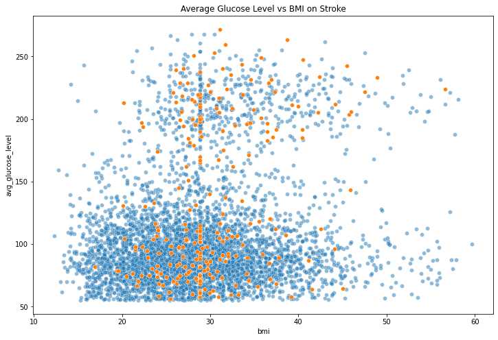

```python
had_stroke = df['stroke'] == 1
no_stroke = df['stroke'] == 0

plt.figure(figsize=(12, 8))

# Plot no_stroke first (makes it easier to see had_stroke values).
sns.scatterplot(data=df[no_stroke], x='bmi', y='avg_glucose_level', alpha=0.5)
sns.scatterplot(data=df[had_stroke], x='bmi', y='avg_glucose_level')

plt.title("Average Glucose Level vs BMI on Stroke")
plt.show()
```

From the scatterplot above, again, those with BMI of 25 or greater have higher chances of getting a stroke.

Looking at the plot, it appears that there are varying average glucose levels that can lead to a stroke. In healthcare, it is known that [elevated glucose levels](https://www.healthline.com/diabetesmine/ask-dmine-can-hypos-cause-strokes#8) contribute to strokes. I thought this was interesting because in the scatterplot, it seems that there is a greater number of people having average glucose levels less than 110 (lower glucose levels) that suffer from strokes. There is currently no evidence that low glucose levels trigger strokes, however, low levels do set up an environment in which, if a stroke happens, it's super-sized. Maybe the strokes with low average glucose levels in the data set are "super-sized" strokes.

### Hypertension, Heart Disease, and Smoking Status

For these attributes, we will be generating plots appropriate for categorical values.

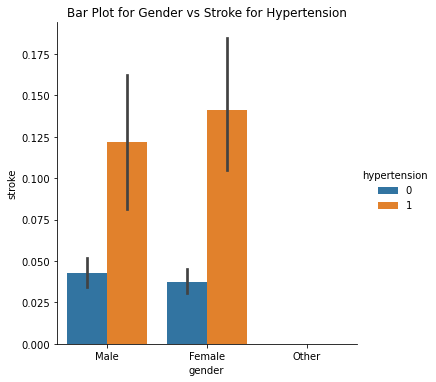

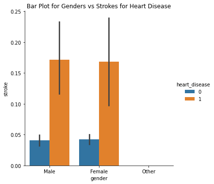

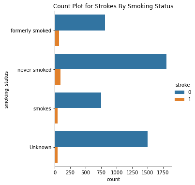

```python
plt.figure(figsize=(8, 6))

# Plot gender vs stroke for hypertension
sns.catplot(data=df, x='gender', y='stroke', hue='hypertension', kind='bar')
plt.title('Bar Plot for Gender vs Stroke for Hypertension')

# Plot gender vs stroke for heart disease
sns.catplot(data=df, x='gender', y='stroke', hue='heart_disease', kind='bar')
plt.title('Bar Plot for Genders vs Strokes for Heart Disease')

# Plot count plot for strokes by smoking status
sns.catplot(data=df, y='smoking_status', hue='stroke', kind='count')
plt.title('Count Plot for Strokes By Smoking Status')
plt.show()
```

As expected, hypertension and heart disease seem correlated to stroke. In both bar plots, gender does not seem to affect whether a person encounters a stroke or not.

It is known that smoking is a major risk factor for strokes. But surprisingly, smoking status does not seem to be correlated to strokes. From a visual observation, the counts/proportions among different smoking_status is fairly equal.

## Machine Learning Algorithms

### Encode categorical attributes

First, let's encode the categorical variables into numerical values so that they can be useful when building a model.

```python
# Convert categorical variables to numerical with LabelEncoder
enc = LabelEncoder()

categorical = ['gender', 'smoking_status', 'work_type', 'residence_type', 'ever_married']

for column in categorical:
    df[column] = enc.fit_transform(df[column])

df.head()
```

|  | gender | age | hypertension | heart_disease | ever_married | work_type | residence_type | avg_glucose_level | bmi | smoking_status | stroke |
| --- | --- | --- | --- | --- | --- | --- | --- | --- | --- | --- | --- |
| 0 | 1 | 67.0 | 0 | 1 | 1 | 2 | 1 | 228.69 | 36.600000 | 1 | 1 |
| 1 | 0 | 61.0 | 0 | 0 | 1 | 3 | 0 | 202.21 | 28.799714 | 2 | 1 |
| 2 | 1 | 80.0 | 0 | 1 | 1 | 2 | 0 | 105.92 | 32.500000 | 2 | 1 |
| 3 | 0 | 49.0 | 0 | 0 | 1 | 2 | 1 | 171.23 | 34.400000 | 3 | 1 |
| 4 | 0 | 79.0 | 1 | 0 | 1 | 3 | 0 | 174.12 | 24.000000 | 2 | 1 |

### Split the data set

Next, we split the data set into the Testing set and Train set.

```python
# Split into x and y (features and value to be predicted)
X = df.drop('stroke', axis=1)
y = df['stroke']

X.shape, y.shape
```

```
((5110, 10), (5110,))
```

```python
X_train, X_test, y_train, y_test = train_test_split(X, y, test_size=0.3, random_state=40)
```

### Balance the data set

Before we can actually build a model, we have to make sure our data set is properly prepared. One of the first things I noticed about the data set was how much entries there are for no strokes (or stroke == 0). This caused the data to be imbalanced. In case you are having trouble imagining an inbalanced data set, let's plot it.

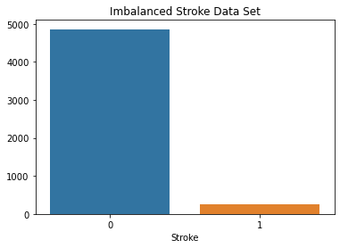

```python
x_counts = df['stroke'].value_counts().index
y_counts = df['stroke'].value_counts().values

sns.barplot(x=x_counts, y=y_counts)

plt.title('Imbalanced Stroke Data Set')
plt.xlabel('Stroke')
plt.show()
```

As you can see, there is a much greater proportion of 'stroke == 0' values compared to 'stroke == 1' (which is what we are actually interested in). Some of the problems with unbalanced data sets are that some models are susceptible to unbalanced data sets. The algorithm might recieve too many examples from a certain class resulting in a biased model. It doesn't learn what makes the other class different and can overfit the majority class.

To balance the data set, we will be up sampling the minority class.

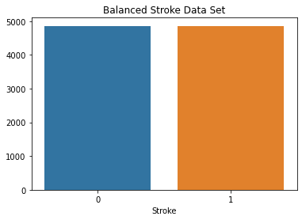

```python
sm = SMOTE(random_state=2)
X, y = sm.fit_resample(X, y)

# Now display the newly updated data set
sns.barplot(x=['0', '1'], y =[sum(y == 0), sum(y == 1)])
plt.title('Balanced Stroke Data Set')
plt.xlabel('Stroke')
plt.show()
```

### Logistic Regression

```python
# Perform logistic regression
loj = LogisticRegression(solver = "liblinear")

# Train model using training sets
loj_model = loj.fit(X_train,y_train)
loj_model

y_pred = loj_model.predict(X_test)

# Check accuracy
score = accuracy_score(y_test, y_pred)

print("Accuracy score: ", '%.2f'% (score*100),"%")
```

```
Accuracy score:  95.37 %
```

The first ML algorithm we performed was logistic regression. We used accuracy as a performance metric and calculated it by comparing test set values and predicted values. The logistic regression resulting in an accuracy of 95.37%, which is considered a "great" accuracy.

### k-NN Classification

Let's try performing another ML algorithm. This time we will perform a k-NN classification, with k=5 initially.

```python
# Create KNN Classifier
knn = KNeighborsClassifier(n_neighbors = 5)

# Train the model using the training sets
knn.fit(X_train, y_train)

y_pred_2 = knn.predict(X_test)

# Check accuracy
k_accuracy = accuracy_score(y_test, y_pred_2)
print("Accuracy: ", '%.2f'% (k_accuracy*100),"%")
# or print(knn.score(X_test, y_test))

# Performing 10-fold cross validation

# Create new KNN model
knn_cv = KNeighborsClassifier(n_neighbors = 5)

# Train model with cv of 10
scores = cross_val_score(knn_cv, X, y, cv = 10)

# Print each cv score (accuracy) and average them
print(scores)
print("cv_scores mean: {}".format(np.mean(scores)))

# Using GridSearchCV in order to find optimal k value for a cv of 10

# Create new a KNN model
knn2 = KNeighborsClassifier()

# Create a dictionary of all values we want to test for n_neighbors

param_grid = {"n_neighbors": np.arange(1, 20)}

# Use gridsearch to test all values for n_neighbors

knn_gscv = GridSearchCV(knn2, param_grid, cv = 10)

# Fit model to data
knn_gscv.fit(X, y)

# Check the optimal performing n_neighbors value (k value)
print("Optimal k value: ", knn_gscv.best_params_)

# Check mean score for optimal performing value of k
print("Mean score for optimal k value: ", knn_gscv.best_score_)
```

```
Accuracy:  94.52 %
[0.89722508 0.90441932 0.89917695 0.89711934 0.8909465  0.88065844
 0.87654321 0.8899177  0.9063786  0.89609053]
cv_scores mean: 0.8938475674486865
Optimal k value:  {'n_neighbors': 2}
Mean score for optimal k value:  0.9246029631321399
```

This algorithm is a bit less accurate than the logistic regression algorithm, but it is still pretty accurate with an accuracy of 94.52%. I also used the 10 fold cross validation to tune the parameters and got an mean score of 0.8938475674486865 after performing the cross folds. I was interested in what would be the most optimal k value for the knn algorithm to improve accuracy. By using GridSearchCV, I see that the most optimal k-value is 2, which results in a mean accuracy/score of 92.46029631321399%.

### Random Forest Classifer

```python
# Train model using training sets
rf_model = RandomForestClassifier().fit(X_train, y_train)

y_pred3 = rf_model.predict(X_test)

score2 = accuracy_score(y_test, y_pred3)

print("Accuracy score: ", '%.2f'% (score2*100),"%")
```

```
Accuracy score:  95.24 %
```

Out of the three algorithms, the logistic regression has the highest accuracy percentage. Let's further analyze how accurate logistic regression algorithm is through another performance measurement: confusion matrix.

```
Confusion Matrix :
 <sklearn.metrics._plot.confusion_matrix.ConfusionMatrixDisplay object at 0x120a0f670>
```

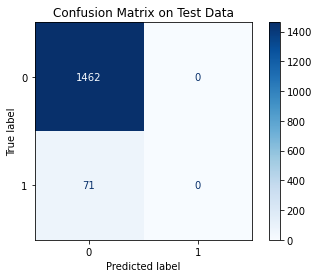

```python
# Generate confusion matrix using test data
cf_matrix = plot_confusion_matrix(loj_model, X_test, y_test, cmap='Blues')

print ("Confusion Matrix : \n", cf_matrix)

plt.title('Confusion Matrix on Test Data')
plt.grid(False)
plt.show()
```

## Conclusion

Although no in-depth statistical analysis or hypothesis testing has been performed yet, we have definitely obseved some potential trends/relationships from our data.

Overall, I hope you were able to learn something about data analysis, data cleaning, data visualization, or Machine Learning algorithms from this tutorial! Data science is so important and cool and allows us to leverage available data to draw conclusions that may even save lives!

## Additional Resources

Here are some additional resources if you need help or are interested in learning more about some of the topics we covered in this tutorial!

- Learning more about strokes: https://www.stroke.org/en/about-stroke
- Python tutorial: https://docs.python.org/3/tutorial/
- Installing Pandas: https://pandas.pydata.org/pandas-docs/stable/install.html
- Exploratory Data Analysis: https://towardsdatascience.com/exploratory-data-analysis-8fc1cb20fd15
- Tidy data: https://towardsdatascience.com/what-is-tidy-data-d58bb9ad2458
- ML Algorithms: https://machinelearningmastery.com/a-tour-of-machine-learning-algorithms/